# Untitled

kjd

January 21, 2018

I wrote about using writer monads in the past and how they can help you make certain tasks much cleaner. I see a lot of stuff on the internet about monads and other functional programming constructs. They often try to explain the theory which can be a difficult task because they are not really a thing so much as what something can do.

There was a funny tweet that said ‘category theory is inerted math, definitions depend on nothing internal and only the things outside’

There was a [great post](https://web.archive.org/web/20130515015225/http://newartisans.com:80/2012/08/monads-in-pictures/) that I was only able to find using the way back machine that ahd some really great pictures showing how monads, among other constructs, work in clear pictures.

### Function

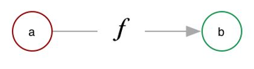

In this picture f is the function and it is mapping things in a to things in b. It is also not doing anything else in the outside world. In R you do this all the time. Albiet lots of times they do have some impact on the outside, which can be useful and can also create a mess.

A few examples of functions.

```r
toupper('a')
```

```
## [1] "A"
```

```r
sqrt(16)
```

```
## [1] 4
```

Something else you can do in R, and many other languages, is apply a function to a collection of things. Here a few examples.

```r
lapply(head(letters), toupper)
```

```
## [[1]]
## [1] "A"
##
## [[2]]
## [1] "B"
##
## [[3]]
## [1] "C"
##
## [[4]]
## [1] "D"
##
## [[5]]
## [1] "E"
##
## [[6]]
## [1] "F"
```

```r
lapply(1:3, `+`, 1)
```

```
## [[1]]
## [1] 2
##
## [[2]]
## [1] 3
##
## [[3]]
## [1] 4
```

```r
map(1:3, `+`, 1)
```

```
## [[1]]
## [1] 2
##
## [[2]]
## [1] 3
##
## [[3]]
## [1] 4
```

### functor

[functor](https://en.wikipedia.org/wiki/Functor) are things that can be mapped over. IN the above we mapped functions over lists and sets. Lists, or any type of collection, is a good starting point but it is certainly not all that can be mapped over.

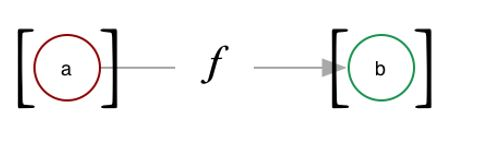

THis pictures shows that a functor can reach into a context, teh square brackets, and grab the a and map them into b that also in some context. For the context here we are talking about being in a column in a tibble as the notion of context. In the post about writer monads we had a context and it was the provenance string.

In Haskell to be a functor you class Functor f where fmap :: (a -> b) -> f a -> f b

and fmap is teh mapping. for a list fmap is map or the following map :: (a -> b) -> [a] -> [b]

And so here we can see this works in R as well as Haskell, the f from fmap is now just the [ for map becuase it is a list. A data.frame like thing is a list of columns, say we want to map over each and take the second item, we would use [ function.

```r
lapply(mtcars, `[`, 2)
```

```
## $mpg
## [1] 21
##
## $cyl
## [1] 6
##
## $disp
## [1] 160
##
## $hp
## [1] 110
##
## $drat
## [1] 3.9
##
## $wt
## [1] 2.875
##
## $qsec
## [1] 17.02
##
## $vs
## [1] 0
##
## $am
## [1] 1
##
## $gear
## [1] 4
##
## $carb
## [1] 4
```

lyahgg The first functor law states that if we map the id function over a functor, the functor that we get back should be the same as the original functor.

The second law says that composing two functions and then mapping the resulting function over a functor should be the same as first mapping one function over the functor and then mapping the other one

Here a few examples.

Build a tibble, which is nothing too interesting. As a side note, a tibble is a more capable data.frame, it provides some strictness in that it wont return columns that you supply partial names to, and it wont automatically create factors, and has a nicer print if you call it so that it does not try to display everything.

```r
df <- tibble(a = 1:10, b = round(runif(10), 2), y = sample(0:1, 10, replace = T))
head(df)
```

```
## # A tibble: 6 x 3
##       a     b     y
##   <int> <dbl> <int>
## 1     1  0.88     1
## 2     2  0.04     0
## 3     3  0.75     0
## 4     4  0.57     0
## 5     5  0.12     0
## 6     6  0.29     1
```

A very interesting thing though that we can do with a tibble that is not feasible with any other data.frame implementation in an any language is add a list column. Which is something that is not a basic number or character, it can even be another tibble or a data.frame.

Here we add a column of graphs, that is each row has its own graph in the column.

```r
df$c <- lapply(1:10, function(x) erdos.renyi.game(rpois(1, 30), .5))
head(df)
```

```
## # A tibble: 6 x 4
##       a     b     y            c
##   <int> <dbl> <int>       <list>
## 1     1  0.88     1 <S3: igraph>
## 2     2  0.04     0 <S3: igraph>
## 3     3  0.75     0 <S3: igraph>
## 4     4  0.57     0 <S3: igraph>
## 5     5  0.12     0 <S3: igraph>
## 6     6  0.29     1 <S3: igraph>
```

```r
df$c[1]
```

```
## [[1]]
## IGRAPH U--- 23 128 -- Erdos renyi (gnp) graph
## + attr: name (g/c), type (g/c), loops (g/l), p (g/n)
## + edges:
##  [1]  1-- 3  1-- 4  2-- 4  3-- 4  1-- 5  2-- 5  5-- 6  2-- 7  4-- 7  1-- 8
## [11]  2-- 8  4-- 8  5-- 8  6-- 8  7-- 8  1-- 9  3-- 9  5-- 9  6-- 9  3--10
## [21]  5--10  7--10  4--11  5--11  7--11 10--11  2--12  3--12  4--12  2--13
## [31]  6--13  9--13 10--13 11--13  2--14  3--14  4--14  5--14  6--14  8--14
## [41]  9--14 10--14  1--15  3--15  5--15  6--15  8--15  9--15 11--15 12--15
## [51] 13--15 14--15  2--16  4--16  8--16  9--16 10--16 12--16 13--16  1--17
## [61]  2--17  4--17  5--17  6--17  7--17  9--17 10--17 11--17  2--18  4--18
## [71]  5--18 10--18 14--18 16--18  1--19  6--19  7--19  9--19 14--19 16--19
## + ... omitted several edges
```

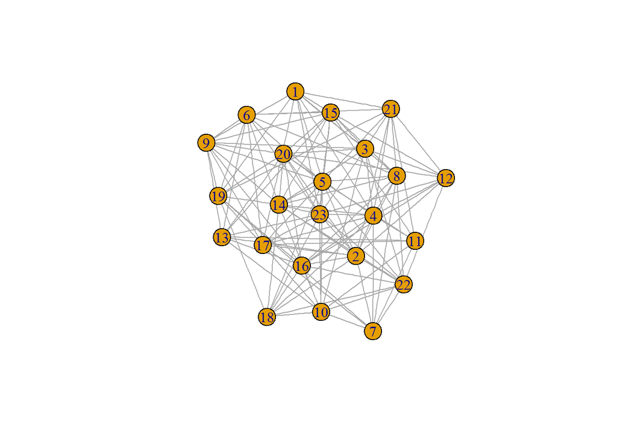

```r
plot(df$c[[1]])
```

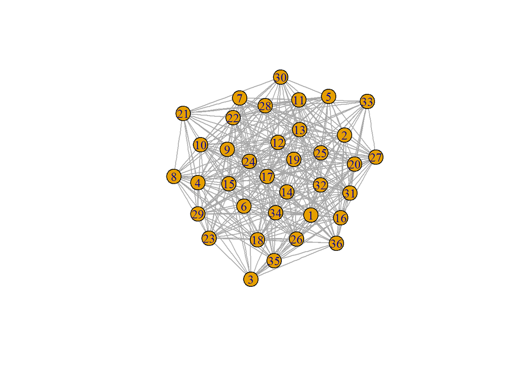

```r
plot(df$c[[2]])
```

This is a collection of them, or graphs in a context.

In the case of tibble we can map over it. We use map_dbl instead of map because R does not have a strong static type system so the function centr_betw_tmax has no type signiture to say what it will return. Since we gave it a list it will return another list, but there is no need to have these numbers in a context, other than that of being a column.

```r
df$c %>% map_dbl(centr_betw_tmax)
```

```
##  [1]  5082 20825 13050 10584 14415 26714  9477  4410 24642  9477
```

So indeed it is a functor. We can use this on our tibble as well.

```r
df %>% mutate(d = map_dbl(c, centr_betw_tmax))
```

```
## # A tibble: 10 x 5
##        a     b     y            c     d
##    <int> <dbl> <int>       <list> <dbl>
##  1     1  0.88     1 <S3: igraph>  5082
##  2     2  0.04     0 <S3: igraph> 20825
##  3     3  0.75     0 <S3: igraph> 13050
##  4     4  0.57     0 <S3: igraph> 10584
##  5     5  0.12     0 <S3: igraph> 14415
##  6     6  0.29     1 <S3: igraph> 26714
##  7     7  0.10     1 <S3: igraph>  9477
##  8     8  0.90     1 <S3: igraph>  4410
##  9     9  0.19     0 <S3: igraph> 24642
## 10    10  0.21     1 <S3: igraph>  9477
```

No on to [applicative](https://en.wikipedia.org/wiki/Applicative_functor). All applicatives are functors. You will commonly see that applicatives are talked about as a way to upgrade functors based on number of arguments. Functors, really fmap, takes things from one value to another, an applicataive allows you to expand this beyond one to one. The number of arguments can be increased but another aspect is the that we gain is the ability to have a function in a context. And not just a fucntion but this can be the part that has many arguemnt, or many functions, and apply them to one or many sets of inputs.

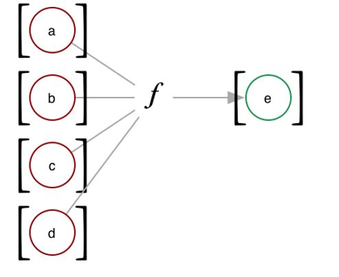

This image only highlights one of the capabilities of applicatives. This shows many sets of input arguments. Think of the map2 function.

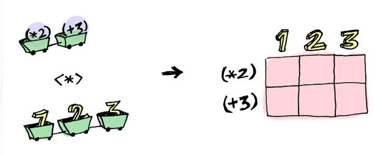

They can also place have many functions and in a context, like a list full of them.

class (Functor f) => Applicative f where pure :: a -> f a (<*>) :: f (a -> b) -> f a -> f b

So make more functions associated to graphs. This devaites a bit from the first image unless we change our thought n waht is what. The lsit of functions is the second argument and function application is the function.

```r
fns <- list(f1 = centr_betw_tmax,
            f2 = assortativity.degree,
            f3 = graph.adhesion,
            f4 = graph.density,
            # We can also partially apply them.
            f5 = partial(average.path.length, directed = F, unconnected = T))
```

Many functions in a context, a list here, applied to one graph. We use a new type of map here since the input is a list of functions and we want a tibble out and also specify the argument it binds to.

```r
fns %>% invoke_map_df(graph = df$c[[1]])
```

```
## # A tibble: 1 x 5
##      f1          f2    f3        f4       f5
##   <dbl>       <dbl> <dbl>     <dbl>    <dbl>
## 1  5082 -0.04324324     8 0.5059289 1.494071
```

We can use many functions on many graphs, both in contexts. lapply is a map (like) thing as well.

```r
lapply(df$c, function(x) fns %>% invoke_map_df(graph = x)) %>% head
```

```
## [[1]]
## # A tibble: 1 x 5
##      f1          f2    f3        f4       f5
##   <dbl>       <dbl> <dbl>     <dbl>    <dbl>
## 1  5082 -0.04324324     8 0.5059289 1.494071
##
## [[2]]
## # A tibble: 1 x 5
##      f1          f2    f3       f4       f5
##   <dbl>       <dbl> <dbl>    <dbl>    <dbl>
## 1 20825 -0.04025899    14 0.531746 1.468254
##
## [[3]]
## # A tibble: 1 x 5
##      f1          f2    f3        f4       f5
##   <dbl>       <dbl> <dbl>     <dbl>    <dbl>
## 1 13050 -0.09803276    10 0.4989247 1.501075
##
## [[4]]
## # A tibble: 1 x 5
##      f1          f2    f3        f4      f5
##   <dbl>       <dbl> <dbl>     <dbl>   <dbl>
## 1 10584 -0.04802048     8 0.4679803 1.53202
##
## [[5]]
## # A tibble: 1 x 5
##      f1          f2    f3        f4       f5
##   <dbl>       <dbl> <dbl>     <dbl>    <dbl>
## 1 14415 -0.01625301    11 0.4858871 1.514113
##
## [[6]]
## # A tibble: 1 x 5
##      f1          f2    f3        f4       f5
##   <dbl>       <dbl> <dbl>     <dbl>    <dbl>
## 1 26714 -0.08589489    13 0.4939271 1.506073
```

This is cool but I it would be nice if they were included back into the tibble instead of having a bunch of new tibbles. If we add this back into the context we have expanded past the functor and the applicative. This is what it means to be a monad, cs def and math category theory def, able to pull out of context eval and put back in so that they can be chained together. We could also do this without needing the intermediate applicative, taht would also be a monad.

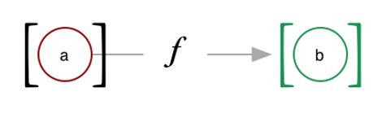

```r
df %>% mutate(d = lapply(c, function(x) fns %>% invoke_map_df(graph = x)))
```

```
## # A tibble: 10 x 5
##        a     b     y            c                d
##    <int> <dbl> <int>       <list>           <list>
##  1     1  0.88     1 <S3: igraph> <tibble [1 x 5]>
##  2     2  0.04     0 <S3: igraph> <tibble [1 x 5]>
##  3     3  0.75     0 <S3: igraph> <tibble [1 x 5]>
##  4     4  0.57     0 <S3: igraph> <tibble [1 x 5]>
##  5     5  0.12     0 <S3: igraph> <tibble [1 x 5]>
##  6     6  0.29     1 <S3: igraph> <tibble [1 x 5]>
##  7     7  0.10     1 <S3: igraph> <tibble [1 x 5]>
##  8     8  0.90     1 <S3: igraph> <tibble [1 x 5]>
##  9     9  0.19     0 <S3: igraph> <tibble [1 x 5]>
## 10    10  0.21     1 <S3: igraph> <tibble [1 x 5]>
```

But it is a list, because tibbles can’t be new columns on their own. We can use unnest to make it look more like normal. We could also override either the pipe or mutate to lift everything capable of being non list in tibble standard form, but that is just syntactic sugar and aesthetics.

```r
df %>%
  mutate(d = lapply(c, function(x) fns %>% invoke_map_df(graph = x))) %>%
  unnest(d)
```

```
## # A tibble: 10 x 9
##        a     b     y            c    f1           f2    f3        f4
##    <int> <dbl> <int>       <list> <dbl>        <dbl> <dbl>     <dbl>
##  1     1  0.88     1 <S3: igraph>  5082 -0.043243243     8 0.5059289
##  2     2  0.04     0 <S3: igraph> 20825 -0.040258988    14 0.5317460
##  3     3  0.75     0 <S3: igraph> 13050 -0.098032760    10 0.4989247
##  4     4  0.57     0 <S3: igraph> 10584 -0.048020478     8 0.4679803
##  5     5  0.12     0 <S3: igraph> 14415 -0.016253009    11 0.4858871
##  6     6  0.29     1 <S3: igraph> 26714 -0.085894885    13 0.4939271
##  7     7  0.10     1 <S3: igraph>  9477  0.008438717     9 0.4656085
##  8     8  0.90     1 <S3: igraph>  4410 -0.172905028     6 0.5064935
##  9     9  0.19     0 <S3: igraph> 24642 -0.009269678    10 0.4836415
## 10    10  0.21     1 <S3: igraph>  9477 -0.047045777     9 0.5264550
## # ... with 1 more variables: f5 <dbl>
```

Now we have all of the components of category theory, not really but enough power to make all the rest. So we can have complex types of data like networks or email conversations and use them in a normal data science process.

We can next create the set of extractors that would create all the relavent features for a conversation. A lot of these would be similar to the ones for an email but there are new ones that are pretty interesting. A few listed here:

1. The length of conversation, or how many atomic emails it contains. I can imagine this being very indicative of spam as nobody would respond.
2. Level of bifurcations or splits, would this indicate cliques of people or hiding bits of a conversation from others.
3. I also imagine there are groups that are fairly common, like back and forths where two people alternate (with and without an audience of other cc’s and to’s), or a role call where one person starts and each person replies with the date that works for them or their thought on something. Probably others as well.
4. The duration of the conversation, is it over a day or two or does it span months/years.

So given a set of these feature extractors, we can apply it to our dataset of conversations and then use the typical feature selection process and supervised learning algorithms and train/test constructs.

Last week I brought up the notion of double and miss counting for emails. This manifests itself in what is typcally known as leaks from the future, or not haivng true hold out data. Another aspect of this which pervades lots of data science is the notion of independent and identiically distributed, [IID](https://en.wikipedia.org/wiki/Independent_and_identically_distributed_random_variables), observations. The Bayesian framework provides a similar notion called [exchangeable](https://en.wikipedia.org/wiki/Exchangeable_random_variables), meaning that you can exchange any two observations and nothing is lost. If you think about things like time series data, they do not adhere to this, you can’t switch the value of a stock from two months ago with that of yesterday and have the same time series. If you have the goal of predicting mortgage defaults though, you are much closer to this, you can swap two mortgages in a data set and not lose anything (ignoring the notion of people who have multiple mortgages).

The current goal of using emails also has this issue, if you swap one email for another it may lead to some form of incoherance becuase other emails point to this one or this one may point to others in a larger conversation. So my thinking going forward is that we can model a conversation instead of an email.

The result is that each item is now iid, or at least more so. This means that each observation in our data set is one conversation isntead of one email or message file. We can also look at all the representative msg that created the conversation and bring any coding they may have to the whole as a target variable.

This type of thing is not done as the ability to use common machine learning models no longer applies when you do not have something that is rectangular like Excel were each row is an entity and each column is a variable. Here we have a complicated structure that is our entity. When things like this do occur they usually require a large effort to build training algorithms that can account for such complexity.

A thought I had though was that we can use the machinary from [Category Theory](https://en.wikipedia.org/wiki/Category_theory) to overcome this hurdle. If you are not familiar with this area of math the gist from Wikipedia may suffice,

‘The study of categories is an attempt to axiomatically capture what is commonly found in various classes of related mathematical structures by relating them to the structure-preserving functions between them.’

If we could take all of the structure that currently exists in supervised machine learning and apply it to things that have the same higher level mathematical structure, we could expidite the process. How would we do this? We need to create a morphism, or a structure preserving mapping from rows of basic entities to conversations of atomic emails (or any more complicated entity.)

I think this would solve our problem, and possibly a great many other machine learning problems.